# Question

A [mass-spring system](https://en.wikipedia.org/wiki/Simple_harmonic_motion#Examples) oscillates over time. The position (in meters) of the mass is plotted as a function of time (in seconds).

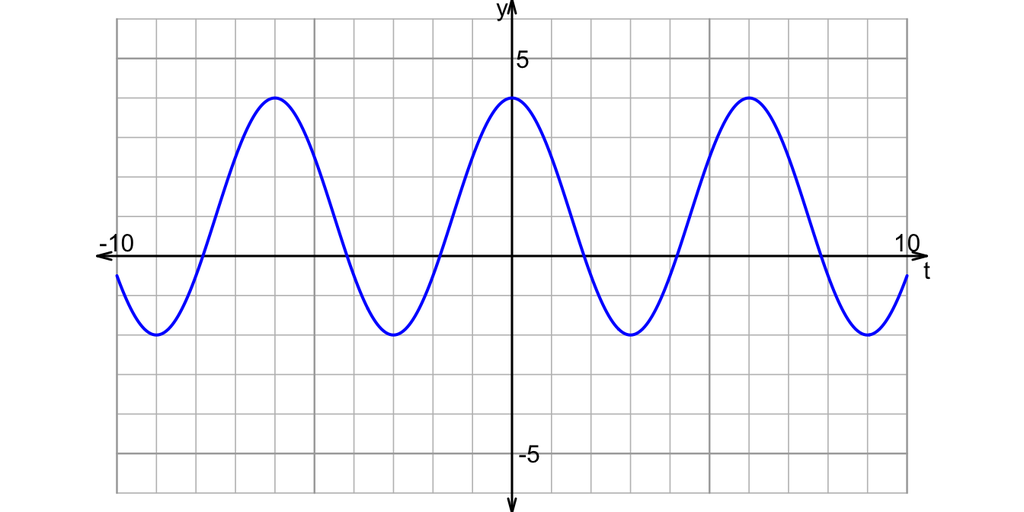

Choose a trigonometric function ($g$), and the parameters ($A$, $B$, and $D$), to model this oscillatory motion.

$$y~=~A\cdot g(Bt)+D$$

- $g=$ ##ANSWER1##
- $A=$ ##ANSWER2##
- $B=$ ##ANSWER3##
- $D=$ ##ANSWER4##

## Answerlist

- sin
- cos
- -4
- -3
- -2
- -1
- 0
- 1
- 2
- 3
- 4
- 3.14
- 1.57
- 1.05
- 0.79
- 0.63
- 0.52
- -3
- -2
- -1
- 0
- 1
- 2
- 3

# Solution

- The amplitude is 3 meters.
- The period is 6 seconds.
- The midline is at 1 meters.

The only calculation needed is to convert the period ($P=6$) into [angular frequency](https://en.wikipedia.org/wiki/Angular_frequency) ($B$) by dividing $2\pi$ by the period.

$$B=\frac{2\pi}{P}$$
$$B=1.0471976$$

The amplitude is the absolute value of $A$.
$$|A|~=~3$$

1. If when $t=0$ (at $y$-axis) the wave is at midline and is increasing, then $A>0$ and $g=\sin$.
2. If when $t=0$ (at $y$-axis) the wave is at midline and is decreasing, then $A<0$ and $g=\sin$.
3. If when $t=0$ (at $y$-axis) the wave is at maximum, then $A>0$ and $g=\cos$.
4. If when $t=0$ (at $y$-axis) the wave is at minimum, then $A<0$ and $g=\cos$.

So, $A=3$ and $g=\cos$. Also, $D=1$.

So,

$$y ~=~ 3\cdot\cos(1.05t)+1$$

- $g=\cos$
- $A=3$
- $B=1.05$
- $D=1$

# Meta-information

extype: cloze exclozetype: schoice|schoice|schoice|schoice exsolution: 01|000000010|001000|0000100 exname: pick_wave_pams